# Genome-wide methylation analysis report

# Genome-wide methylation analysis report

- study: Pleural cfDNAm analysis of hannum.platevariable
- author: Paul Yousefi
- date: 08 October, 2026

## Parameters

```
## $sig.threshold
## [1] 2.121143e-07
##
## $max.plots
## [1] 10
##
## $qq.inflation.method
## [1] "median"
##
## $practical.threshold
## [1] 2.074006e-16
```

## Sample characteristics

For continuous or ordinal variables, the “mean” column provides the mean and the “sd/%” column the standard deviation of the variable. For categorical variables, the “mean” column provides the number of samples with the given “value” and the “sd/%” column the percentage of samples with the given “value”.

| variable | value | mean | sd.. |
| --- | --- | --- | --- |
| hannum |  | 66.14647 | 15.75662 |
| plate |  | 2.319218 | 1.048991 |
| sv1 |  | -1.084202e-19 | 0.0571662 |
| sv2 |  | -4.240462e-19 | 0.0571662 |
| sv3 |  | -1.339758e-18 | 0.0571662 |
| sv4 |  | 1.930214e-18 | 0.0571662 |
| sv5 |  | 4.483591e-19 | 0.0571662 |
| sv6 |  | 3.862978e-18 | 0.0571662 |
| sv7 |  | -6.777627e-18 | 0.0571662 |
| sv8 |  | 1.043854e-18 | 0.0571662 |
| sv9 |  | 2.684261e-18 | 0.0571662 |
| sv10 |  | 1.558519e-16 | 0.0571662 |

## Covariate associations

### Covariate plate

statistics

| var1 | var2 | F | p-value | R | p-value |
| --- | --- | --- | --- | --- | --- |
| hannum | plate | 0.7868837 | 0.375743 | 0.0425024 | 0.4580872 |

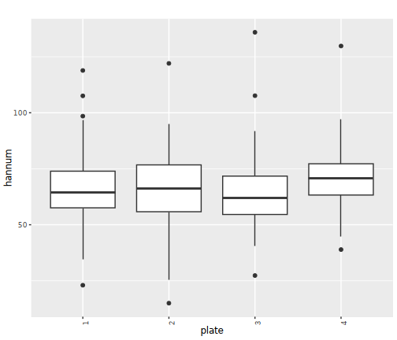

### Covariate sv1

statistics

| var1 | var2 | F | p-value | R | p-value |
| --- | --- | --- | --- | --- | --- |
| hannum | sv1 | 7.222467 | 0.0075948 | 0.1430662 | 0.0121495 |

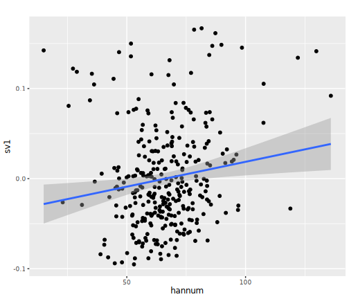

### Covariate sv2

statistics

| var1 | var2 | F | p-value | R | p-value |
| --- | --- | --- | --- | --- | --- |
| hannum | sv2 | 1.065997 | 0.3026694 | 0.0722502 | 0.2066776 |

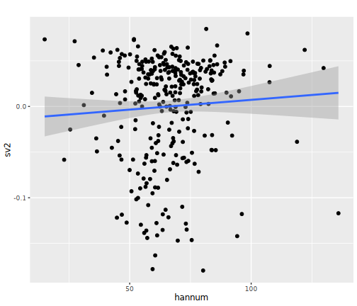

### Covariate sv3

statistics

| var1 | var2 | F | p-value | R | p-value |
| --- | --- | --- | --- | --- | --- |
| hannum | sv3 | 0.0340549 | 0.8537127 | 0.0368115 | 0.5202895 |

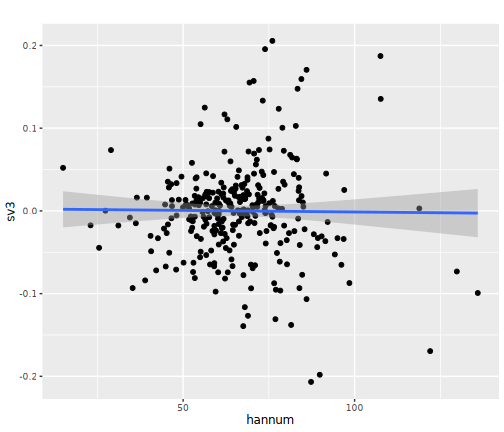

### Covariate sv4

statistics

| var1 | var2 | F | p-value | R | p-value |
| --- | --- | --- | --- | --- | --- |
| hannum | sv4 | 1.977798 | 0.1606406 | 0.1052539 | 0.0655279 |

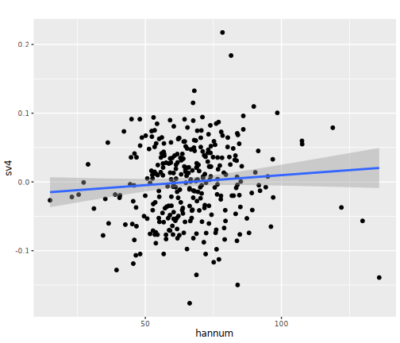

### Covariate sv5

statistics

| var1 | var2 | F | p-value | R | p-value |
| --- | --- | --- | --- | --- | --- |
| hannum | sv5 | 23.48471 | 2e-06 | -0.3010869 | 1e-07 |

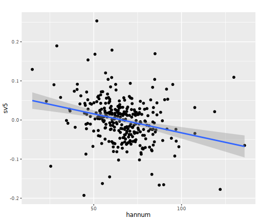

### Covariate sv6

statistics

| var1 | var2 | F | p-value | R | p-value |
| --- | --- | --- | --- | --- | --- |
| hannum | sv6 | 10.2523 | 0.0015093 | 0.1234832 | 0.0305928 |

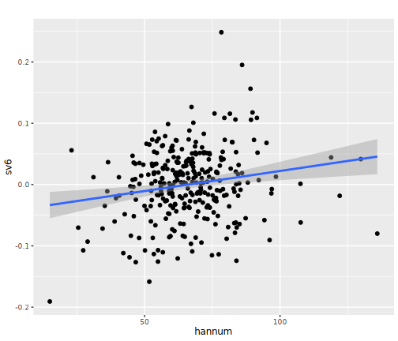

### Covariate sv7

statistics

[output not shown]

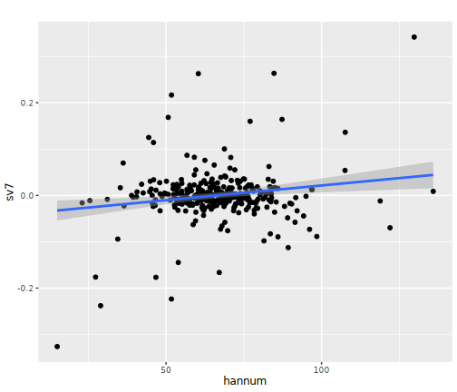

### Covariate sv8

statistics

| var1 | var2 | F | p-value | R | p-value |
| --- | --- | --- | --- | --- | --- |
| hannum | sv8 | 2.940859 | 0.0873805 | -0.0558312 | 0.3293616 |

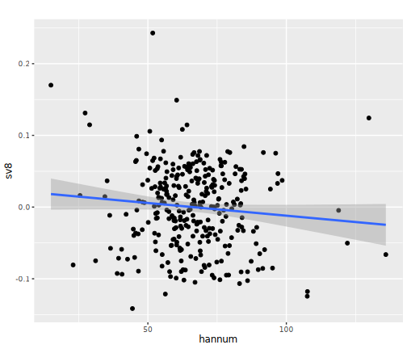

### Covariate sv9

statistics

| var1 | var2 | F | p-value | R | p-value |
| --- | --- | --- | --- | --- | --- |
| hannum | sv9 | 6.393922 | 0.0119554 | -0.1053112 | 0.0653809 |

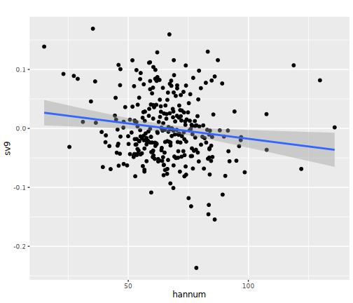

### Covariate sv10

statistics

| var1 | var2 | F | p-value | R | p-value |
| --- | --- | --- | --- | --- | --- |
| hannum | sv10 | 0.1134221 | 0.7365128 | 0.0084685 | 0.8824531 |

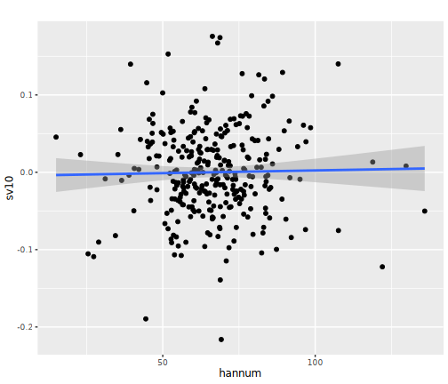

## QQ plots

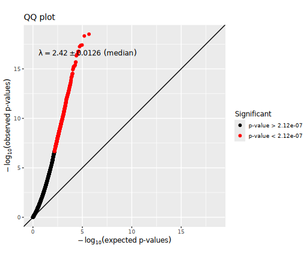

## Manhattan plots

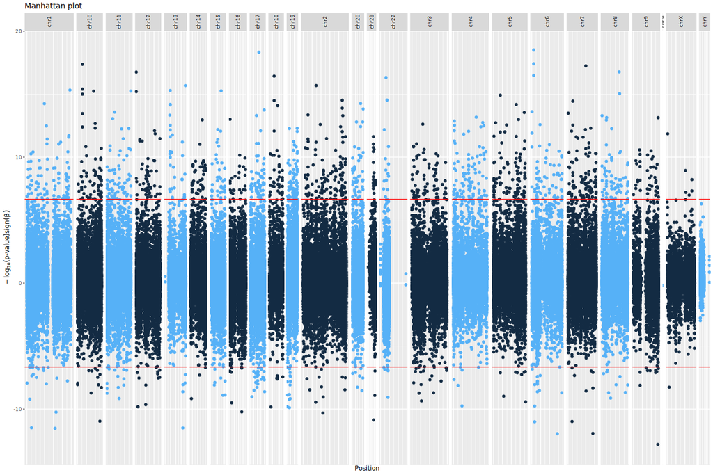

## Significant CpG sites

There were 1533 CpG sites with association p-values < 2.1211427 × 10<sup>-7</sup>. These are listed in the file associations.csv.

Below are the 10 CpG sites with association p-values < 2.0740057 × 10<sup>-16</sup> in the regression model.

|  | chromosome | position | estimate | p.value | p.adjust |
| --- | --- | --- | --- | --- | --- |
| cg09157076 | chr6 | 11044880 | 0.0038947 | 0 | 0 |
| cg11071401 | chr17 | 48637194 | 0.0035942 | 0 | 0 |
| cg24724428 | chr6 | 11044888 | 0.0046485 | 0 | 0 |
| cg02487453 | chr22 | 31198724 | 0.0017971 | 0 | 0 |
| cg21572722 | chr6 | 11044894 | 0.0028356 | 0 | 0 |
| cg16024950 | chr7 | 100254149 | 0.0038230 | 0 | 0 |
| cg13702996 | chr12 | 176189 | 0.0026598 | 0 | 0 |
| cg05694245 | chr10 | 28034816 | 0.0018901 | 0 | 0 |
| cg21859781 | chr8 | 97173034 | 0.0023861 | 0 | 0 |
| cg25789861 | chr18 | 28622940 | 0.0024309 | 0 | 0 |

Plots of these sites follow, one for each covariate set. “p[lm]” denotes the p-value obtained using a linear model and “p[beta]” the p-value obtained using beta regression.

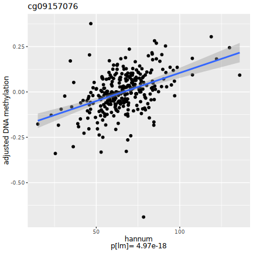

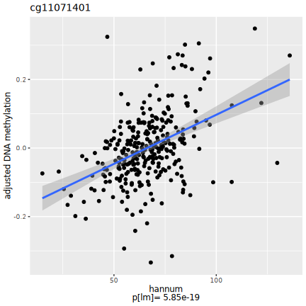

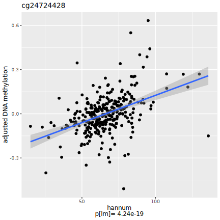

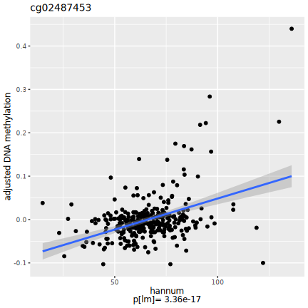

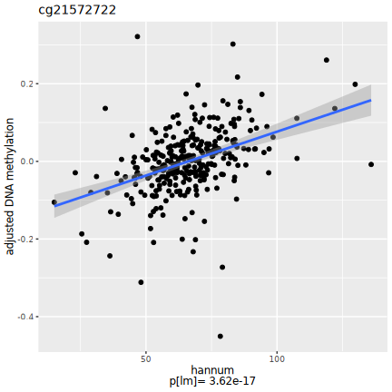

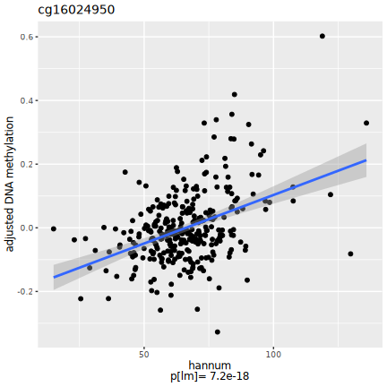

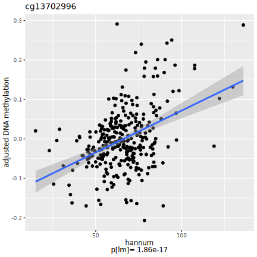

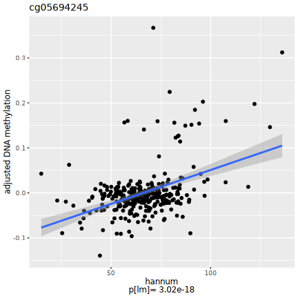

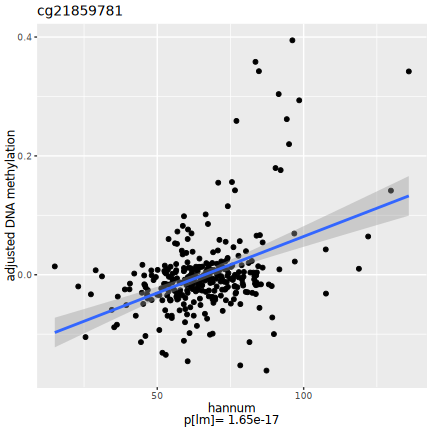

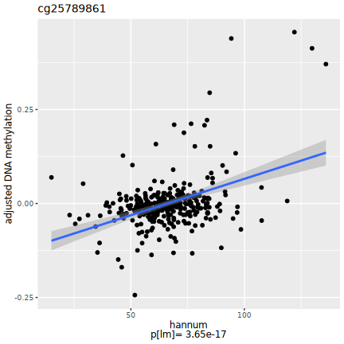

## Selected CpG sites

Number of CpG sites selected: 0.

| chromosome | position | estimate | p.value | p.adjust |
| --- | --- | --- | --- | --- |